# Test a Perceptual Phenomenon

### Analyzing the Stroop Effect

Perform the analysis in the space below. Remember to follow [the instructions](https://docs.google.com/document/d/1-OkpZLjG_kX9J6LIQ5IltsqMzVWjh36QpnP2RYpVdPU/pub?embedded=True) and review the [project rubric](https://review.udacity.com/#!/rubrics/71/view) before submitting. Once you've completed the analysis and write-up, download this file as a PDF or HTML file, upload that PDF/HTML into the workspace here (click on the orange Jupyter icon in the upper left then Upload), then use the Submit Project button at the bottom of this page. This will create a zip file containing both this .ipynb doc and the PDF/HTML doc that will be submitted for your project.

(1) What is the independent variable? What is the dependent variable?

The **independent** variable is the word (congruent or incongruent). The **dependent** variable is the time it takes to read a word.

(2) What is an appropriate set of hypotheses for this task? Specify your null and alternative hypotheses, and clearly define any notation used. Justify your choices.

There is a difference with regards to the time to read a word between the congruent population and the incongruent population. A more specific hypothese would be: the incongruent population required more time to read the words compared to the congruent population.

Null hypothesis: $H_0 = µ_C - µ_I = 0$

Alternative hypothesis: $H_1 = µ_C - µ_I ≠ 0$

The hypothesis says that there is no difference between the two groups in terms of "mean time required to read a (congruent/incongruent) word".

To test the hypothesis I am going to use the **bootstrapping method** which will help to understand the sampling distribution. It is a good approach because we do not have to assume a distribution which we do can not know from the provided data.

(3) Report some descriptive statistics regarding this dataset. Include at least one measure of central tendency and at least one measure of variability. The name of the data file is 'stroopdata.csv'.

```python
import pandas as pd
import numpy as np
import matplotlib.pyplot as plt
import scipy.stats
%matplotlib inline

df = pd.read_csv('stroopdata.csv')
```

```python
df.describe()
```

|  | Congruent | Incongruent |
| --- | --- | --- |
| count | 24.000000 | 24.000000 |
| mean | 14.051125 | 22.015917 |
| std | 3.559358 | 4.797057 |
| min | 8.630000 | 15.687000 |
| 25% | 11.895250 | 18.716750 |
| 50% | 14.356500 | 21.017500 |
| 75% | 16.200750 | 24.051500 |
| max | 22.328000 | 35.255000 |

```python
# calculating the mean reading time of the congruent group

co_mean = df['Congruent'].mean()
co_mean
```

```
14.051124999999999
```

```python
# calculating the mean reading time of the incongruent group

in_mean = df['Incongruent'].mean()
in_mean
```

```
22.015916666666666
```

```python
# calculating the mean difference between the two groups

diff = co_mean - in_mean
diff = abs(diff)
diff
```

```
7.9647916666666667
```

To show a **measure of central tendency** I would argue that only 24 values are not sufficient. I am therefore bootstrapping to approximate the true population data.

```python
# bootstrapping with a small sample

bs_diff_100 = []
for x in range(100):
    bs_sample = df.sample(24, replace=True)
    bs_co_mean = bs_sample['Congruent'].mean()
    bs_in_mean = bs_sample['Incongruent'].mean()
    bs_diff_100.append(abs(bs_co_mean - bs_in_mean))

np.array(bs_diff_100).mean()
```

```
7.8307674999999985
```

```python
# bootstrapping with a medium sized sample

bs_diff_1000 = []
for x in range(1000):
    bs_sample = df.sample(24, replace=True)
    bs_co_mean = bs_sample['Congruent'].mean()
    bs_in_mean = bs_sample['Incongruent'].mean()
    bs_diff_1000.append(abs(bs_co_mean - bs_in_mean))

np.array(bs_diff_1000).mean()
```

```
7.9867614166666661
```

```python
# bootstrapping with a large sample

bs_diff_10000 = []
for x in range(10000):
    bs_sample = df.sample(24, replace=True)
    bs_co_mean = bs_sample['Congruent'].mean()
    bs_in_mean = bs_sample['Incongruent'].mean()
    bs_diff_10000.append(abs(bs_co_mean - bs_in_mean))

np.array(bs_diff_10000).mean()
```

```
7.963941908333334
```

The initial observed difference (diff) is similar to the bootstrapped samples (bs_diff_100, bs_diff_1000, bs_diff_1000). One could argue that this is because of the data used and the characteristics thereof.

(4) Provide one or two visualizations that show the distribution of the sample data. Write one or two sentences noting what you observe about the plot or plots.

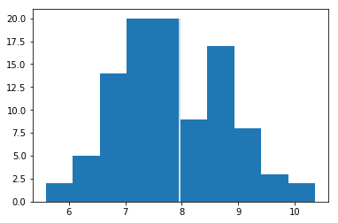

```python
# plotting a histogram for the small sample

plt.hist(bs_diff_100);
plt.axvline(diff, color='white');
```

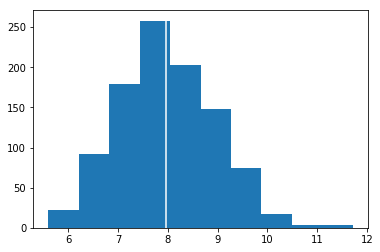

```python
# plotting a histogram for the medium sized sample

plt.hist(bs_diff_1000);
plt.axvline(diff, color='white');
```

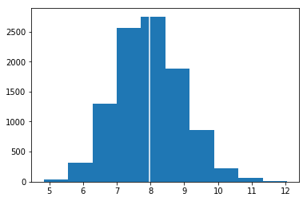

```python
# plotting a histogram for the large sample

plt.hist(bs_diff_10000);
plt.axvline(diff, color='white');
```

The observed mean difference of the initial data falls right into the middle of the bootstrapped samples.

(5) Now, perform the statistical test and report your results. What is your confidence level or Type I error associated with your test? What is your conclusion regarding the hypotheses you set up? Did the results match up with your expectations? **Hint:** Think about what is being measured on each individual, and what statistic best captures how an individual reacts in each environment.

#### Contiuning with Bootstraping

... as suggested by the most recent review and to stay consistent with the current analytical approach.

```python
# compute statistics (mean time and standard deviation) for the original sample

co_mean = df['Congruent'].mean()
in_mean = df['Incongruent'].mean()
co_std = df['Congruent'].std()
in_std = df['Incongruent'].std()
obs_diff = in_mean - co_mean
obs_diff
```

```
7.9647916666666667
```

```python
# creating a sampling distribution of the differences in times

sim_t_diffs = []
for x in range(10000):
    boot_sample = df.sample(df.shape[0], replace=True)
    co_mean = boot_sample['Congruent'].mean()
    in_mean = boot_sample['Incongruent'].mean()
    sim_t_diffs.append(in_mean - co_mean)
```

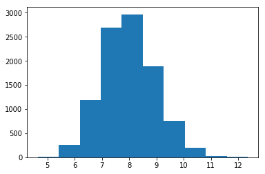

```python
# convert to an array and print a histogram

sim_t_diffs = np.array(sim_t_diffs)
plt.hist(sim_t_diffs);
```

```python
# simulate the sampling distribution under the null hypthesis

null_diffs = np.random.normal(0, sim_t_diffs.std(), sim_t_diffs.size)
```

```python
# compute p-value

p_val = (null_diffs > obs_diff).mean()
p_val
```

```
0.0
```

A small p-value is an indicator to the reject the null hypthesis. In this case we reject the null hypothesis which is that there is no difference between the two groups in terms of "mean time required to read a (congruent/incongruent) word".

The p-value therefore allows us to say that there is a difference between the two groups.

(6) Optional: What do you think is responsible for the effects observed? Can you think of an alternative or similar task that would result in a similar effect? Some research about the problem will be helpful for thinking about these two questions!